# Effect Size

```r
library(lme4)
library(effectsize)
library(emmeans)
library(tidyverse)
```

## `lmer`

With linear mixed-effects models, the main problem is about which standard deviation using to standardize a certain effect.

```r
ns <- 100
nt <- 50
cond <- c(0.5, -0.5)
b0 <- 0.2
b1 <- 0.5
sb0 <- 0.2
sb1 <- 0.05
s <- 1 # residual standard deviation
dat <- expand_grid(id = 1:ns, trial = 1:nt, cond = cond)

b0i <- rnorm(ns, 0, sb0)
b1i <- rnorm(ns, 0, sb1)

dat$y <- with(dat, b0 + b0i[id] + (b1 + b1i[id]) * cond) + rnorm(nrow(dat), 0, s)

fit <- lmer(y ~ cond + (cond||id), data = dat) # no correlation slopes-intercept
summary(fit)
```

```
Linear mixed model fit by REML ['lmerMod']
Formula: y ~ cond + ((1 | id) + (0 + cond | id))
   Data: dat

REML criterion at convergence: 28655.4

Scaled residuals:
    Min      1Q  Median      3Q     Max
-3.7267 -0.6642  0.0094  0.6722  3.4730

Random effects:
 Groups   Name        Variance Std.Dev.
 id       (Intercept) 0.031841 0.17844
 id.1     cond        0.004496 0.06705
 Residual             1.011468 1.00572
Number of obs: 10000, groups:  id, 100

Fixed effects:
            Estimate Std. Error t value
(Intercept)  0.20016    0.02048   9.772
cond         0.47993    0.02120  22.636

Correlation of Fixed Effects:
     (Intr)
cond 0.000
```

In this situation we have different options. Firstly, let’s compute the standard Cohen’s $d$ without considering the model:

```r
effectsize::cohens_d(y ~ cond, data = dat, paired = TRUE)
```

```
Cohen's d |         95% CI
--------------------------
-0.34     | [-0.36, -0.31]
```

```r
effectsize::cohens_d(y ~ cond, data = dat, paired = FALSE)
```

```
Cohen's d |         95% CI
--------------------------
-0.47     | [-0.51, -0.43]

- Estimated using pooled SD.
```

Then we can aggregate first and then compute the $d$:

```r
dat |>
  group_by(id, cond) |>
  summarise(y = mean(y)) |>
  cohens_d(y ~ cond, data = _)
```

[output not shown]

```
Cohen's d |         95% CI
--------------------------
-2.08     | [-2.42, -1.73]

- Estimated using pooled SD.
```

Here we are ignoring the uncertainty at the trial level and considering only the between-subjects differences.

From the model we can directly compute these quantities:

```r
get_variance <- function(fit, which = NULL){
  vv <- data.frame(VarCorr(fit))
  vi <- vv$vcov
  names(vi) <- tolower(ifelse(is.na(vv$var1), "residual", gsub("\\(|\\)", "", vv$var1)))
  if(!is.null(which)){
    sum(vi[which])
  }else{
    vi
  }
}

# using residual standard deviation
fixef(fit)["cond"] / sqrt(get_variance(fit)["residual"])
```

```
     cond
0.4772027
```

```r
# using only random (intercepts and slopes) standard deviation
fixef(fit)["cond"] / sqrt(get_variance(fit, c("intercept", "cond")))
```

```
    cond
2.517719
```

```r
# total variance
fixef(fit)["cond"] / sqrt(get_variance(fit, c("intercept", "cond", "residual")))
```

```
     cond
0.4688553
```

Comparing it with the between-subjects Cohen’s $d$ the model is essentially always computing the between version. The paired works on the differences.

Some references:

- https://imaging.mrc-cbu.cam.ac.uk/statswiki/FAQ/tdunpaired
- https://psycnet.apa.org/record/2014-32656-001

## `glmer`

Let’s see an example with a `glm`. Let’s simulate data similar to the previous example but when the response is binary accuracy. The effect size now can be computed as odds ratio. The odds of a probability is calculated as $p / (1 - p)$ and is interpreted as the number of successes for each failure (or the opposite). For example, $p = 0.7$ corresponds to an odds of 2.3333333, thus 2.3333333 successes for each failure. Taking the log of the odds create a symmetric function with midpoint on zero.

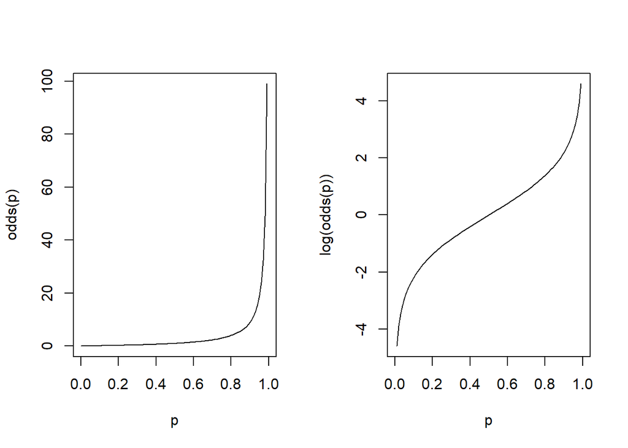

```r
odds <- function(p) p / (1 - p)
p <- seq(0, 1, 0.01)
par(mfrow = c(1,2))
plot(p, odds(p), type = "l")
plot(p, log(odds(p)), type = "l")
```

With two conditions or groups, we can compute the ratio of two odds (odds ratio) intepreted as the increase in the odds of success at the numerator compared to the denominator. The OR is an effect size that can be directly intepreted but can also be derived from other effect sizes.

```r
effectsize::oddsratio_to_d(OR = 3) # d associated with an OR of 3
```

```
[1] 0.6056967
```

```r
effectsize::d_to_oddsratio(d = 0.4) # OR for a d = 0.4
```

```
[1] 2.065805
```

Now we can simulate data and see how to compute an appropriate effect size:

```r
dat <- expand_grid(id = 1:ns, trial = 1:nt, cond = cond)

b0 <- qlogis(0.7)
b1 <- log(2) # ~ cohen's d = 0.4
sb0 <- 0.3
sb1 <- 0.05

b0i <- rnorm(ns, 0, sb0)
b1i <- rnorm(ns, 0, sb1)

p <- plogis(with(dat, b0 + b0i[id] + (b1 + b1i[id]) * cond))
dat$y <- rbinom(nrow(dat), 1, p)

fit <- glmer(y ~ cond + (cond|id), data = dat, family = binomial(link = "logit"))
summary(fit)
```

```
Generalized linear mixed model fit by maximum likelihood (Laplace
  Approximation) [glmerMod]
 Family: binomial  ( logit )
Formula: y ~ cond + (cond | id)
   Data: dat

     AIC      BIC   logLik deviance df.resid
 12124.4  12160.5  -6057.2  12114.4     9995

Scaled residuals:
    Min      1Q  Median      3Q     Max
-2.3111 -1.1341  0.5554  0.6866  1.1251

Random effects:
 Groups Name        Variance Std.Dev. Corr
 id     (Intercept) 0.08973  0.2996
        cond        0.02515  0.1586   -0.61
Number of obs: 10000, groups:  id, 100

Fixed effects:
            Estimate Std. Error z value Pr(>|z|)
(Intercept)  0.81497    0.03744   21.77   <2e-16 ***
cond         0.71220    0.04764   14.95   <2e-16 ***
---
Signif. codes:  0 '***' 0.001 '**' 0.01 '*' 0.05 '.' 0.1 ' ' 1

Correlation of Fixed Effects:
     (Intr)
cond -0.087
```

Now we can estimate our effect size. Let’s start by analyzing accuracies using a linear model:

```r
dat |>
  group_by(id, cond) |>
  summarise(y = mean(y)) |>
  effectsize::cohens_d(y ~ cond, paired = TRUE, data = _)
```

[output not shown]

```
Cohen's d |         95% CI
--------------------------
-1.48     | [-1.77, -1.20]
```

```r
dat |>
  group_by(id, cond) |>
  summarise(y = mean(y)) |>
  effectsize::cohens_d(y ~ cond, paired = FALSE, data = _)
```

[output not shown]

```
Cohen's d |         95% CI
--------------------------
-1.63     | [-1.95, -1.31]

- Estimated using pooled SD.
```

Now let’s transform the model coefficient into a Cohen’s $d$:

```r
exp(fixef(fit)) # odds ratio
```

```
(Intercept)        cond
   2.259108    2.038464
```

```r
effectsize::logoddsratio_to_d(fixef(fit)["cond"])
```

```
     cond
0.3926546
```